# Basic Text Mining in R

Philip Murphy, PhD

4/4/2017

# Basic Text Mining in R

[Back to the QDA Course Site](https://sites.google.com/site/qdaatmiis/) **Note: The QDA Course Site** is open only to students that are, or have been, registered for the Qualitative Data Analysis course at the [Middlebury Institute of International Studies at Monterey.](http://miis.edu/)

**To start,** install the packages you need to mine text  
You only need to do this step once.

```r
Needed <- c("tm", "SnowballCC", "RColorBrewer", "ggplot2", "wordcloud", "biclust",
    "cluster", "igraph", "fpc")
install.packages(Needed, dependencies = TRUE)

install.packages("Rcampdf", repos = "http://datacube.wu.ac.at/", type = "source")
```

If you get the following message:  
‘Update all/some/none? [a/s/n]:’ enter “a” and press return

## Loading Texts

Start by saving your text files in a folder titled: “texts” This will be the “corpus” (body) of texts you are mining.

**Note:** The texts used in this example are a few of Donald Trump’s speeches that were copied and pasted into a text document. You can use a variety of media for this, such as PDF and HTML. The text example was chosen out of curiosity. If you would like to use these same texts, you can [download them here.](https://drive.google.com/open?id=0B914dXn0AXvlaWhmVXdPclZrTjA)

*Read this next part carefully.* You need to do three unique things here:  
1. Create a file named “texts” where you’ll keep your data.  
2. Save the file to a particular place  
+ **Mac**: Desktop  
+ **PC**: C: drive  
3. Copy and paste the appropriate scripts below.

**On a Mac**, save the folder to your desktop and use the following code chunk:

```r
cname <- file.path("~", "Desktop", "texts")
cname
```

```
## [1] "~/Desktop/texts"
```

```r
dir(cname)   # Use this to check to see that your texts have loaded.
```

```
##  [1] "Trump Black History Month Speech.txt"
##  [2] "Trump CIA Speech.txt"
##  [3] "Trump Congressional Address.txt"
##  [4] "Trump CPAC Speech.txt"
##  [5] "Trump Florida Rally 2-18-17.txt"
##  [6] "Trump Immigration Speech 8-31-16.txt"
##  [7] "Trump Inauguration Speech.txt"
##  [8] "Trump National Prayer Breakfast.txt"
##  [9] "Trump Nomination Speech.txt"
## [10] "Trump Police Chiefs Speech.txt"
## [11] "Trump Response to Healthcare Bill Failure.txt"
```

**On a PC**, save the folder to your C: drive and use the following code chunk:

```r
cname <- file.path("C:", "texts")
cname
dir(cname)
```

**Load the R package for text mining and then load your texts into R.**

```r
library(tm)
docs <- VCorpus(DirSource(cname))
summary(docs)
```

```
##                                               Length Class
## Trump Black History Month Speech.txt          2      PlainTextDocument
## Trump CIA Speech.txt                          2      PlainTextDocument
## Trump Congressional Address.txt               2      PlainTextDocument
## Trump CPAC Speech.txt                         2      PlainTextDocument
## Trump Florida Rally 2-18-17.txt               2      PlainTextDocument
## Trump Immigration Speech 8-31-16.txt          2      PlainTextDocument
## Trump Inauguration Speech.txt                 2      PlainTextDocument
## Trump National Prayer Breakfast.txt           2      PlainTextDocument
## Trump Nomination Speech.txt                   2      PlainTextDocument
## Trump Police Chiefs Speech.txt                2      PlainTextDocument
## Trump Response to Healthcare Bill Failure.txt 2      PlainTextDocument
##                                               Mode
## Trump Black History Month Speech.txt          list
## Trump CIA Speech.txt                          list
## Trump Congressional Address.txt               list
## Trump CPAC Speech.txt                         list
## Trump Florida Rally 2-18-17.txt               list
## Trump Immigration Speech 8-31-16.txt          list
## Trump Inauguration Speech.txt                 list
## Trump National Prayer Breakfast.txt           list
## Trump Nomination Speech.txt                   list
## Trump Police Chiefs Speech.txt                list
## Trump Response to Healthcare Bill Failure.txt list
```

For details about documents in the corpus, use the `inspect(docs)` command.

```r
inspect(docs[1])
```

```
## <<VCorpus>>
## Metadata:  corpus specific: 0, document level (indexed): 0
## Content:  documents: 1
##
## [[1]]
## <<PlainTextDocument>>
## Metadata:  7
## Content:  chars: 3974
```

If you so desire, you can read your documents in the R terminal using `writeLines(as.character(docs))`. Or, if you prefer to look at only one of the documents you loaded, then you can specify which one using something like:

```r
writeLines(as.character(docs[1]))
```

```
## list(list(content = c("Well, the election, it came out really well. Next time we’ll triple the number or quadruple it. We want to get it over 51, right? At least 51.", "", "Well this is Black History Month, so this is our little breakfast, our little get-together. Hi Lynn, how are you? Just a few…
## "", "Last month, we celebrated the life of Reverend Martin Luther King, Jr., whose incredible example is unique in American history. You read all about Dr. Martin Luther King a week ago when somebody said I took the statue out of my office. It turned out that that was fake news. Fake news. The st…
## "", "I am very proud now that we have a museum on the National Mall where people can learn about Reverend King, so many other things. Frederick Douglass is an example of somebody who’s done an amazing job and is being recognized more and more, I noticed. Harriet Tubman, Rosa Parks, and millions m…
## "", "We’re gonna need better schools and we need them soon. We need more jobs, we need better wages, a lot better wages. We’re gonna work very hard on the inner city. Ben is gonna be doing that, big league. That’s one of the big things that you’re gonna be looking at. We need safer communities an…
## "", "I’m ready to do my part, and I will say this: We’re gonna work together. This is a great group, this is a group that’s been so special to me. You really helped me a lot. If you remember I wasn’t going to do well with the African-American community, and after they heard me speaking and talkin…
## "", "So I want to thank everybody for being here."), meta = list(author = character(0), datetimestamp = list(sec = 7.1230309009552, min = 40, hour = 1, mday = 6, mon = 3, year = 117, wday = 4, yday = 95, isdst = 0), description = character(0), heading = character(0), id = "Trump Black History Mon…
## list()
## list()
```

## Preprocessing

**Once you are sure that all documents loaded properly, go on to preprocess your texts.**  
This step allows you to remove numbers, capitalization, common words, punctuation, and otherwise prepare your texts for analysis.  
This can be somewhat time consuming and picky, but it pays off in the end in terms of high quality analyses.

*Removing punctuation:*  
Your computer cannot actually read. Punctuation and other special characters only look like more words to your computer and R. Use the following to methods to remove them from your text.

```r
docs <- tm_map(docs,removePunctuation)
# writeLines(as.character(docs[1])) # Check to see if it worked.
    # The 'writeLines()' function is commented out to save space.
```

*If necesasry, such as when working with standardized documents or emails, you can remove special characters.*  
This list has been customized to remove punctuation that you commonly find in emails. You can customize what is removed by changing them as you see fit, to meet your own unique needs.

```r
for (j in seq(docs)) {
    docs[[j]] <- gsub("/", " ", docs[[j]])
    docs[[j]] <- gsub("@", " ", docs[[j]])
    docs[[j]] <- gsub("\\|", " ", docs[[j]])
    docs[[j]] <- gsub("\u2028", " ", docs[[j]])  # This is an ascii character that did not translate, so it had to be removed.
}
# writeLines(as.character(docs[1])) # You can check a document (in this case
# the first) to see if it worked.
```

*Removing numbers:*

```r
docs <- tm_map(docs, removeNumbers)
# writeLines(as.character(docs[1])) # Check to see if it worked.
```

*Converting to lowercase:*  
As before, we want a word to appear exactly the same every time it appears. We therefore change everything to lowercase.

```r
docs <- tm_map(docs, tolower)
docs <- tm_map(docs, PlainTextDocument)
DocsCopy <- docs
# writeLines(as.character(docs[1])) # Check to see if it worked.
```

*Removing “stopwords” (common words) that usually have no analytic value.*  
In every text, there are a lot of common, and uninteresting words (a, and, also, the, etc.). Such words are frequent by their nature, and will confound your analysis if they remain in the text.

```r
# For a list of the stopwords, see:
# length(stopwords("english"))
# stopwords("english")
docs <- tm_map(docs, removeWords, stopwords("english"))
docs <- tm_map(docs, PlainTextDocument)
# writeLines(as.character(docs[1])) # Check to see if it worked.
```

*Removing particular words:*  
If you find that a particular word or two appear in the output, but are not of value to your particular analysis. You can remove them, specifically, from the text.

```r
docs <- tm_map(docs, removeWords, c("syllogism", "tautology"))
# Just remove the words "syllogism" and "tautology".
# These words don't actually exist in these texts. But this is how you would remove them if they had.
```

*Combining words that should stay together*  
If you wish to preserve a concept is only apparent as a collection of two or more words, then you can combine them or reduce them to a meaningful acronym before you begin the analysis. Here, I am using examples that are particular to qualitative data analysis.

```r
for (j in seq(docs))
{
  docs[[j]] <- gsub("fake news", "fake_news", docs[[j]])
  docs[[j]] <- gsub("inner city", "inner-city", docs[[j]])
  docs[[j]] <- gsub("politically correct", "politically_correct", docs[[j]])
}
docs <- tm_map(docs, PlainTextDocument)
```

*Removing common word endings* (e.g., “ing”, “es”, “s”)  
This is referred to as “stemming” documents. We stem the documents so that a word will be recognizable to the computer, despite whether or not it may have a variety of possible endings in the original text.

Note: The “stem completion” function is currently problemmatic, and stemmed words are often annoying to read. For now, I have this section commented out. But you are welcome to try these functions (by removing the hashmark from the beginning of the line) if they interest you. Just don’t expect them to operate smoothly.

This procedure has been a little hanky in the recent past, so I change the name of the data object when I do this to keep from overwriting what I have done to this point.

```r
## Note: I did not run this section of code for this particular example.
docs_st <- tm_map(docs, stemDocument)
docs_st <- tm_map(docs_st, PlainTextDocument)
writeLines(as.character(docs_st[1])) # Check to see if it worked.
# docs <- docs_st
```

Then add common endings to improve intrepretability.

```r
# This appears not to be working right now. You are welcome to try it, but there are numerous reports of
#   the stemCompletion function not being currently operational.
# Note: This code was not run for this particular example either.
#   Read it as a potential how-to.
docs_stc <- tm_map(docs_st, stemCompletion, dictionary = DocsCopy, lazy=TRUE)
docs_stc <- tm_map(docs_stc, PlainTextDocument)
writeLines(as.character(docs_stc[1])) # Check to see if it worked.
# docs <- docs_stc
```

If the stemming and/or stem completion worked, then convert the corpus beck to “docs” using ‘docs <- docs_st’ or ‘docs <- docs_stc’.

*Stripping unnecesary whitespace from your documents:*  
The above preprocessing will leave the documents with a lot of “white space”. White space is the result of all the left over spaces that were not removed along with the words that were deleted. The white space can, and should, be removed.

```r
docs <- tm_map(docs, stripWhitespace)
# writeLines(as.character(docs[1])) # Check to see if it worked.
```

**To Finish**  
**Be sure to use the following script once you have completed preprocessing.**  
This tells R to treat your preprocessed documents as text documents.

```r
docs <- tm_map(docs, PlainTextDocument)
```

*This is the end of the preprocessing stage.*

### Stage the Data

**To proceed, create a document term matrix.**  
*This is what you will be using from this point on.*

```r
dtm <- DocumentTermMatrix(docs)
dtm
```

```
## <<DocumentTermMatrix (documents: 11, terms: 3610)>>
## Non-/sparse entries: 8376/31334
## Sparsity           : 79%
## Maximal term length: 19
## Weighting          : term frequency (tf)
```

To inspect, you can use: `inspect(dtm)`  
This will, however, fill up your terminal quickly. So you may prefer to view a subset:  
`inspect(dtm[1:5, 1:20])` view first 5 docs & first 20 terms - modify as you like  
`dim(dtm)` This will display the number of documents & terms (in that order)

You’ll also need a transpose of this matrix. Create it using:

```r
tdm <- TermDocumentMatrix(docs)
tdm
```

```
## <<TermDocumentMatrix (terms: 3610, documents: 11)>>
## Non-/sparse entries: 8376/31334
## Sparsity           : 79%
## Maximal term length: 19
## Weighting          : term frequency (tf)
```

## Explore your data

Organize terms by their frequency:

```r
freq <- colSums(as.matrix(dtm))
length(freq)
```

```
## [1] 3610
```

```r
ord <- order(freq)
```

If you prefer to export the matrix to Excel:

```r
m <- as.matrix(dtm)
dim(m)
```

```
## [1]   11 3610
```

```r
write.csv(m, file="DocumentTermMatrix.csv")
```

### Focus!

Er, that is, you can focus on just the interesting stuff…  
The ‘removeSparseTerms()’ function will remove the infrequently used words, leaving only the most well-used words in the corpus.

```r
#  Start by removing sparse terms:
dtms <- removeSparseTerms(dtm, 0.2) # This makes a matrix that is 20% empty space, maximum.
dtms
```

```
## <<DocumentTermMatrix (documents: 11, terms: 91)>>
## Non-/sparse entries: 886/115
## Sparsity           : 11%
## Maximal term length: 11
## Weighting          : term frequency (tf)
```

### Word Frequency

There are a lot of terms, so for now, just check out some of the **most and least frequently occurring words.**

```r
freq <- colSums(as.matrix(dtm))
```

**Check out the frequency of frequencies.**  
The ‘colSums()’ function generates a table reporting how often *each word frequency* occurs. Using the ’head()" function, below, we can see the distribution of the least-frequently used words.

```r
head(table(freq), 20) # The ", 20" indicates that we only want the first 20 frequencies. Feel free to change that number.
```

```
## freq
##    1    2    3    4    5    6    7    8    9   10   11   12   13   14   15
## 1602  615  324  212  126  103   77   57   60   51   38   32   29   24   22
##   16   17   18   19   20
##   16    8   15   15   11
```

The resulting output is two rows of numbers. The top number is the frequency with which words appear and the bottom number reflects how many words appear that frequently. Here, considering only the 20 lowest word frequencies, we can see that 1602 terms appear only once. There are also a lot of others that appear very infrequently.

For a look at the most frequently used terms, we can use the ‘tail()’ function.

```r
tail(table(freq), 20) # The ", 20" indicates that we only want the last 20 frequencies.  Feel free to change that number, as needed.
```

```
## freq
##  76  77  79  83  88  95 101 102 105 107 111 122 127 139 140 163 174 265
##   1   1   2   2   1   1   2   2   1   1   1   1   1   1   1   1   1   1
## 279 428
##   1   1
```

Considering only the 20 greatest frequencies, we can see that there is a huge disparity in how frequently some terms appear.

**For a less, fine-grained look at term freqency** we can view a table of the terms we selected when we removed sparse terms, above. (Look just under the word “Focus”.)

```r
freq <- colSums(as.matrix(dtms))
freq
```

```
##        also      always     america    american     another        back
##          54          24         122         107          22          75
##         bad     believe         big        came         can        care
##          35          60          45          20         101          37
##        come     country         day   different        done        dont
##          55         174          36          16          24          95
## enforcement        even        ever       every         get     getting
##          43          55          42          49          79          23
##        give       going        good       great       group      happen
##          25         265          58         163          20          36
##         ive         job        just        know        last         law
##          35          38          88         127          44          59
##         let        life        like      little        long        look
##          40          27          79          24          36          52
##         lot        love        made        many        much        must
##          44          45          33         101          68          53
##      nation        need       never         new         now      office
##          48          32          83          69         111          24
##         one      people   president         put      really    remember
##         139         279          46          35          57          27
##       right        safe        said         say         see        seen
##         102          35          83          66          48          34
##   something     special      states        take        tell       thank
##          25          26          67          64          50         105
##       thats      things       think        time       today    together
##          74          40          77          76          33          34
##     totally       truly  understand      united        want         way
##          18          16          29          64         140          71
##        well        weve        will        work       world        year
##          55          43         428          64          56          47
##       years
##          54
```

The above matrix was created using a data transformation we made earlier. What follows is an alternative that will accomplish essentially the same thing.

```r
freq <- sort(colSums(as.matrix(dtm)), decreasing=TRUE)
head(freq, 14)
```

```
##     will   people    going  country    great     want      one     know
##      428      279      265      174      163      140      139      127
##  america      now american    thank    right   theyre
##      122      111      107      105      102      102
```

**An alternate view of term frequency:**  
This will identify all terms that appear frequently (in this case, 50 or more times).

```r
findFreqTerms(dtm, lowfreq=50)   # Change "50" to whatever is most appropriate for your text data.
```

```
##  [1] "also"        "america"     "american"    "back"        "believe"
##  [6] "can"         "come"        "country"     "dont"        "even"
## [11] "get"         "going"       "good"        "great"       "immigration"
## [16] "jobs"        "just"        "know"        "law"         "like"
## [21] "look"        "make"        "many"        "much"        "must"
## [26] "never"       "new"         "now"         "one"         "people"
## [31] "really"      "right"       "said"        "say"         "states"
## [36] "take"        "tell"        "thank"       "thats"       "theyre"
## [41] "think"       "time"        "united"      "want"        "way"
## [46] "well"        "will"        "work"        "world"       "years"
```

**Yet another way to do this:**

```r
wf <- data.frame(word=names(freq), freq=freq)
head(wf)
```

```
##            word freq
## will       will  428
## people   people  279
## going     going  265
## country country  174
## great     great  163
## want       want  140
```

### Plot Word Frequencies

**Plot words that appear at least 50 times.**

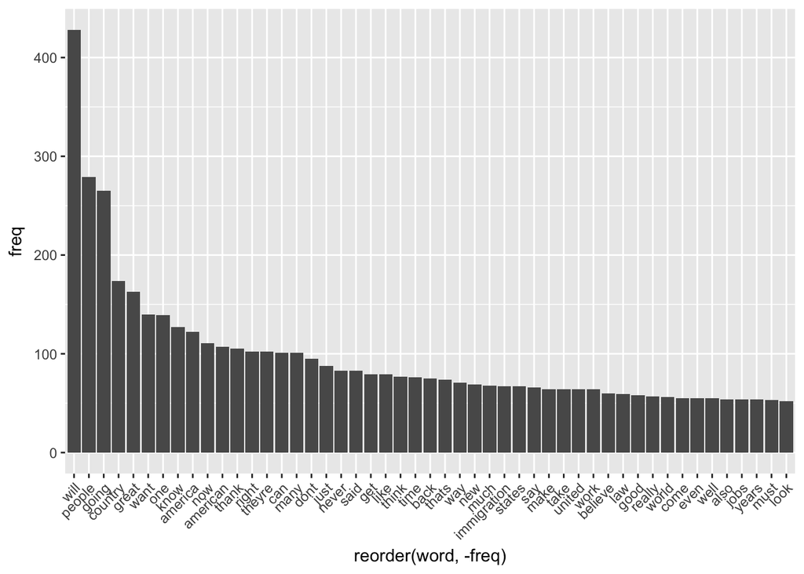

```r
library(ggplot2)
p <- ggplot(subset(wf, freq>50), aes(x = reorder(word, -freq), y = freq)) +
          geom_bar(stat = "identity") +
          theme(axis.text.x=element_text(angle=45, hjust=1))
p
```

## Relationships Between Terms

### Term Correlations

If you have a term in mind that you have found to be particularly meaningful to your analysis, then you may find it helpful to identify the words that most highly correlate with that term.

If words always appear together, then correlation=1.0.

```r
findAssocs(dtm, c("country" , "american"), corlimit=0.85) # specifying a correlation limit of 0.85
```

```
## $country
##    cities countries   nothing      jobs      come   biggest    donors
##      0.94      0.94      0.94      0.92      0.91      0.90      0.90
##    second     begin    border      plan    crimes     globe     meant
##      0.90      0.88      0.88      0.88      0.87      0.87      0.87
## thousands     means   workers      also   despite      take
##      0.87      0.86      0.86      0.85      0.85      0.85
##
## $american
##  restore     task     fair   budget    cycle      new promises  dollars
##     0.97     0.93     0.92     0.91     0.89     0.89     0.89     0.88
##  finally millions national     tens  foreign   middle  justice  program
##     0.88     0.88     0.88     0.88     0.87     0.87     0.86     0.86
##    break  joining   united
##     0.85     0.85     0.85
```

In this case, “country” and “american” were highly correlated with numerous other terms. Setting `corlimit=` to 0.85 prevented the list from being overly long. Feel free to adjust the `corlimit=` to any value you feel is necessary.

```r
findAssocs(dtms, "think", corlimit=0.70) # specifying a correlation limit of 0.95
```

```
## $think
## really   well   care    lot happen    see   good
##   0.89   0.87   0.86   0.76   0.72   0.72   0.71
```

### Word Clouds!

Humans are generally strong at visual analytics. That is part of the reason that these have become so popular. What follows are a variety of alternatives for constructing word clouds with your text.

**Plot words that occur at least 25 times.**

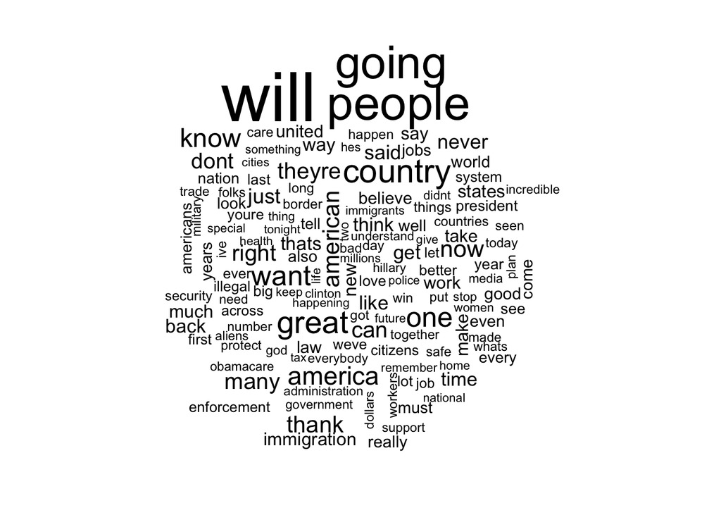

```r
set.seed(142)
wordcloud(names(freq), freq, min.freq=25)
```

**Note:** The “set.seed() function just makes the configuration of the layout of the clouds consistent each time you plot them. You can omit that part if you are not concerned with preserving a particular layout.

**Plot the 100 most frequently used words.**

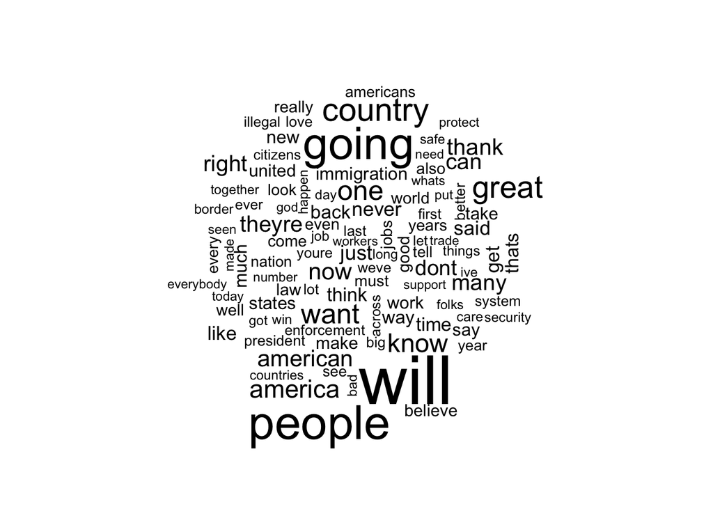

```r
set.seed(142)
wordcloud(names(freq), freq, max.words=100)
```

**Add some color and plot words occurring at least 20 times.**

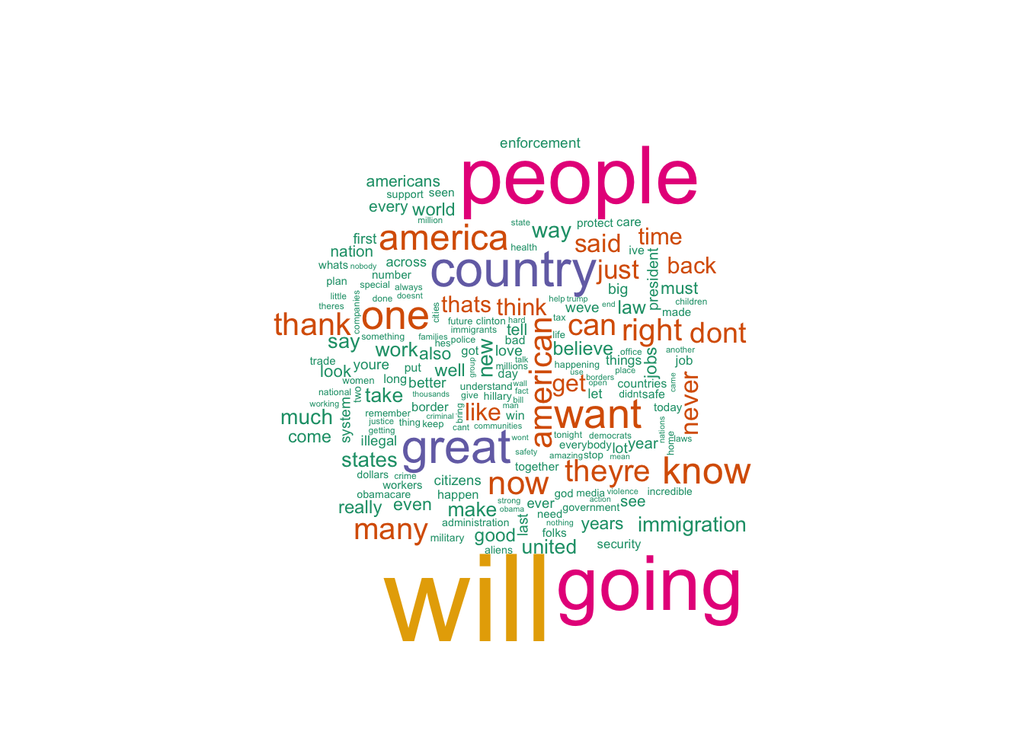

```r
set.seed(142)
wordcloud(names(freq), freq, min.freq=20, scale=c(5, .1), colors=brewer.pal(6, "Dark2"))
```

**Plot the 100 most frequently occurring words.**

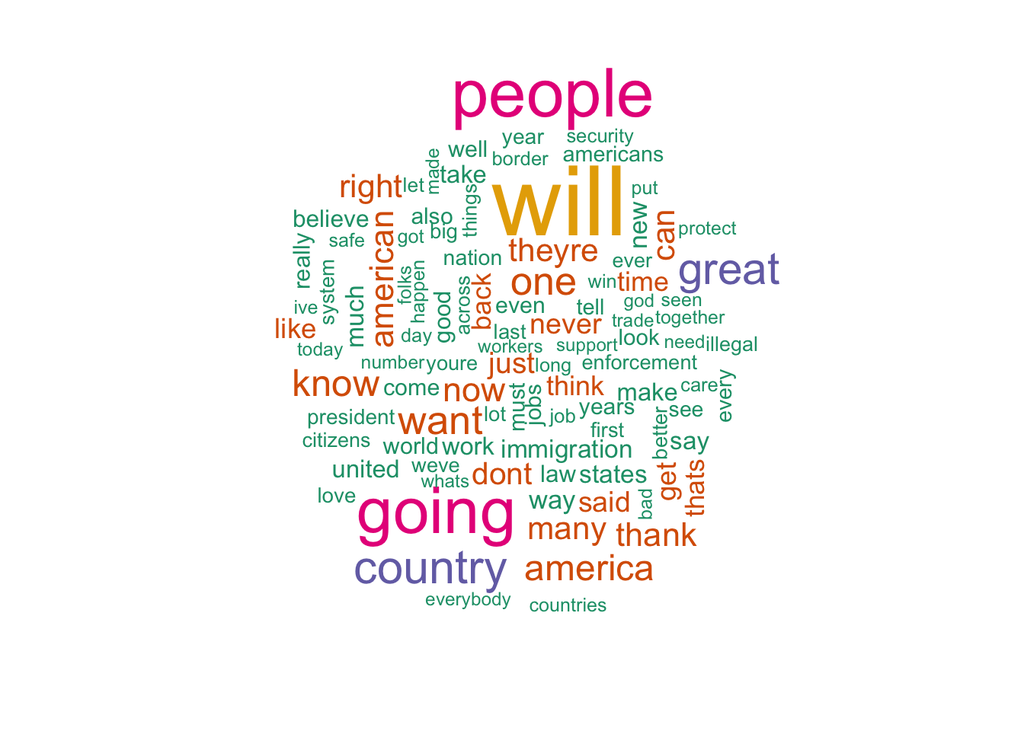

```r
set.seed(142)
dark2 <- brewer.pal(6, "Dark2")
wordcloud(names(freq), freq, max.words=100, rot.per=0.2, colors=dark2)
```

## Clustering by Term Similarity

To do this well, you should always first remove a lot of the uninteresting or infrequent words. If you have not done so already, you can remove these with the following code.

```r
dtmss <- removeSparseTerms(dtm, 0.15) # This makes a matrix that is only 15% empty space, maximum.
dtmss
```

```
## <<DocumentTermMatrix (documents: 11, terms: 45)>>
## Non-/sparse entries: 472/23
## Sparsity           : 5%
## Maximal term length: 9
## Weighting          : term frequency (tf)
```

### Hierarchal Clustering

First calculate distance between words & then cluster them according to similarity.

```r
library(cluster)
d <- dist(t(dtmss), method="euclidian")
fit <- hclust(d=d, method="complete")   # for a different look try substituting: method="ward.D"
fit
```

```
##
## Call:
## hclust(d = d, method = "complete")
##
## Cluster method   : complete
## Distance         : euclidean
## Number of objects: 45
```

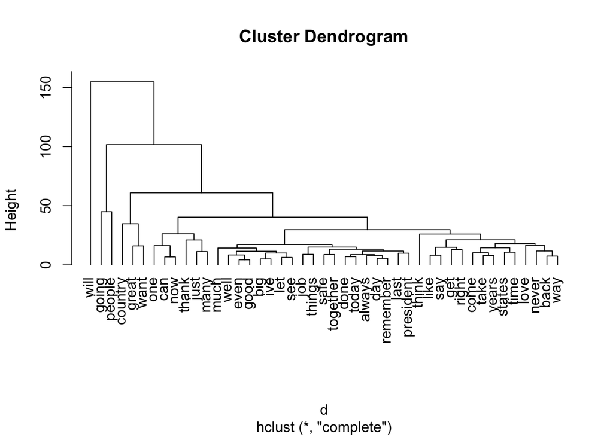

```r
plot(fit, hang=-1)
```

Some people find dendrograms to be fairly clear to read. Others simply find them perplexing. Here, we can see two, three, four, five, six, seven, or many more groups that are identifiable in the dendrogram.

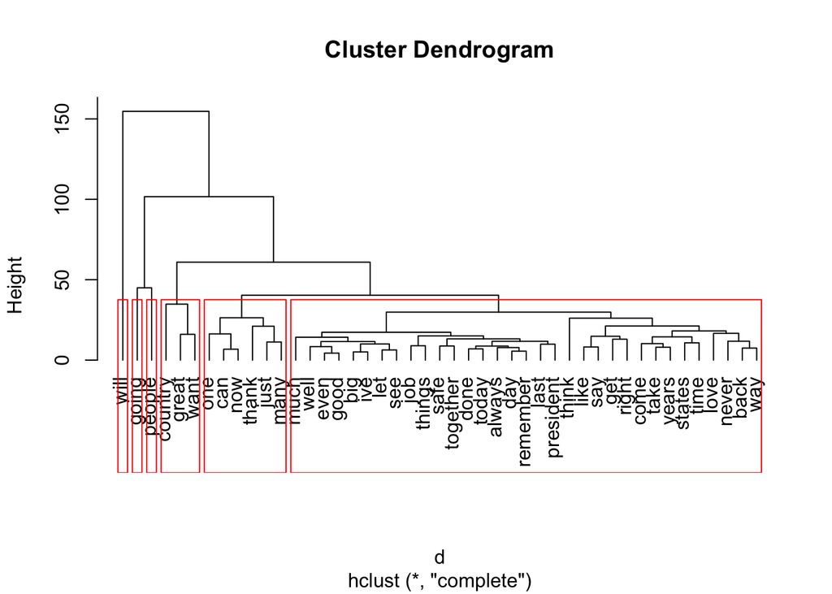

```r
plot.new()
plot(fit, hang=-1)
groups <- cutree(fit, k=6)   # "k=" defines the number of clusters you are using
rect.hclust(fit, k=6, border="red") # draw dendogram with red borders around the 6 clusters
```

### K-means clustering

The k-means clustering method will attempt to cluster words into a specified number of groups (in this case 2), such that the sum of squared distances between individual words and one of the group centers. You can change the number of groups you seek by changing the number specified within the `kmeans()` command.

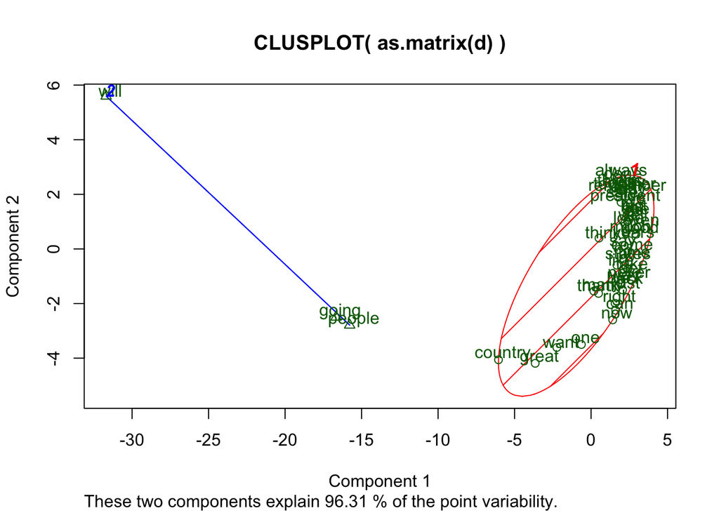

```r
library(fpc)
d <- dist(t(dtmss), method="euclidian")
kfit <- kmeans(d, 2)
clusplot(as.matrix(d), kfit$cluster, color=T, shade=T, labels=2, lines=0)
```

To learn more about text mining specifically, or data mining in general, there is an [online course by Graham Williams](http://onepager.togaware.com/), author of [Data Mining with Rattle and R: The Art of Excavating Data for Knowledge Discovery](http://www.amazon.com/gp/product/1441998896/ref=as_li_qf_sp_asin_tl?ie=UTF8&tag=togaware-20&linkCode=as2&camp=217145&creative=399373&creativeASIN=1441998896). Quite a lot of the material above was initially derived from his “Text Mining” segment.

[Back to the QDA Mashup Site](https://sites.google.com/site/miisqda/)

## Just the Basics

*If all you want to do is try this out*, then use the abbreviated scripts below. You can always go back to read the material above if you want to better understand what you have done later.

*Install needed R packages*  
You only need to do this once

```r
# **To start,** install the packages you need to mine text
#      You only need to do this step once.

Needed <- c("tm", "SnowballCC", "RColorBrewer", "ggplot2", "wordcloud", "biclust",
"cluster", "igraph", "fpc")
install.packages(Needed, dependencies=TRUE)

install.packages("Rcampdf", repos = "http://datacube.wu.ac.at/", type = "source")

# If you get the following message:
#       Update all/some/none? [a/s/n]:
#   enter "a" and press return
##########################################################################################
```

*Tell your computer where to find the texts*  
Read this next part carefully. You need to to three unique things here:  
1. Create a file named “texts” where you’ll keep your data.  
2. Save the file to a particular place  
+ **Mac**: Desktop  
+ **PC**: C: drive  
3. Copy and paste the appropriate scripts below.

```r
##########################################################################################
#                                  Loading Texts                                         #
##########################################################################################
#
#     Start by saving your text files in a folder titled:    "texts"
#     This will be the "corpus" (body) of texts you are mining.
#
#     Next, choose the type of computer you have...



######
# **On a Mac**, save the folder to your *desktop* and use the following code chunk:
######
cname <- file.path("~", "Desktop", "texts")
cname
dir(cname)   # Use this to check to see that your texts have loaded.



######
# *On a PC*, save the folder to your *C: drive* and use the following code chunk:
######
cname <- file.path("C:", "texts")
cname
dir(cname)
##########################################################################################
##########################################################################################
```

*Run the Analyses*

```r
##########################################################################################
#                                Start Your Analyses                                     #
##########################################################################################
# **Load the R package for text mining and then load your texts into R.**
library(tm)
docs <- VCorpus(DirSource(cname))
## Preprocessing
docs <- tm_map(docs,removePunctuation)
docs <- tm_map(docs, removeNumbers)
docs <- tm_map(docs, tolower)
docs <- tm_map(docs, removeWords, stopwords("english"))
docs <- tm_map(docs, removeWords, c("syllogism", "tautology"))
docs <- tm_map(docs, stripWhitespace)
docs <- tm_map(docs, PlainTextDocument)
# *This is the end of the preprocessing stage.*


### Stage the Data
dtm <- DocumentTermMatrix(docs)
tdm <- TermDocumentMatrix(docs)

### Explore your data
freq <- colSums(as.matrix(dtm))
length(freq)
ord <- order(freq)
m <- as.matrix(dtm)
dim(m)
write.csv(m, file="DocumentTermMatrix.csv")
### FOCUS - on just the interesting stuff...
#  Start by removing sparse terms:
dtms <- removeSparseTerms(dtm, 0.1) # This makes a matrix that is 10% empty space, maximum.
### Word Frequency
head(table(freq), 20)
# The above output is two rows of numbers. The top number is the frequency with which
# words appear and the bottom number reflects how many words appear that frequently.
#
tail(table(freq), 20)
# Considering only the 20 greatest frequencies
#
# **View a table of the terms after removing sparse terms, as above.
freq <- colSums(as.matrix(dtms))
freq
# The above matrix was created using a data transformation we made earlier.
# **An alternate view of term frequency:**
# This will identify all terms that appear frequently (in this case, 50 or more times).
findFreqTerms(dtm, lowfreq=50)   # Change "50" to whatever is most appropriate for your data.
#
#
#
### Plot Word Frequencies
# **Plot words that appear at least 50 times.**
library(ggplot2)
wf <- data.frame(word=names(freq), freq=freq)
p <- ggplot(subset(wf, freq>50), aes(word, freq))
p <- p + geom_bar(stat="identity")
p <- p + theme(axis.text.x=element_text(angle=45, hjust=1))
p
#
## Relationships Between Terms
### Term Correlations
# See the description above for more guidance with correlations.
# If words always appear together, then correlation=1.0.
findAssocs(dtm, c("country" , "american"), corlimit=0.85) # specifying a correlation limit of 0.85
findAssocs(dtms, "think", corlimit=0.70) # specifying a correlation limit of 0.95
#
# Change "country" & "american", or "think" to terms that actually appear in your texts.
# Also adjust the `corlimit= ` to any value you feel is necessary.
#
#
### Word Clouds!
# First load the package that makes word clouds in R.
library(wordcloud)
dtms <- removeSparseTerms(dtm, 0.15) # Prepare the data (max 15% empty space)
freq <- colSums(as.matrix(dtm)) # Find word frequencies
dark2 <- brewer.pal(6, "Dark2")
wordcloud(names(freq), freq, max.words=100, rot.per=0.2, colors=dark2)

### Clustering by Term Similarity

### Hierarchal Clustering
dtms <- removeSparseTerms(dtm, 0.15) # This makes a matrix that is only 15% empty space.
library(cluster)
d <- dist(t(dtms), method="euclidian")   # First calculate distance between words
fit <- hclust(d=d, method="complete")    # Also try: method="ward.D"
plot.new()
plot(fit, hang=-1)
groups <- cutree(fit, k=6)   # "k=" defines the number of clusters you are using
rect.hclust(fit, k=6, border="red") # draw dendogram with red borders around the 5 clusters

### K-means clustering
library(fpc)
library(cluster)
dtms <- removeSparseTerms(dtm, 0.15) # Prepare the data (max 15% empty space)
d <- dist(t(dtms), method="euclidian")
kfit <- kmeans(d, 2)
clusplot(as.matrix(d), kfit$cluster, color=T, shade=T, labels=2, lines=0)
```

[Back to the QDA Course Site](https://sites.google.com/site/qdaatmiis/) **Note: The QDA Course Site** is open only to students that are, or have been, registered for the Qualitative Data Analysis course at the [Middlebury Institute of International Studies at Monterey.](http://miis.edu/)